# Ex1

## Exploration 1. Portrait Mode & Semantic Segmentation

### Background: Understanding Semantic Segmentation

##### 1. Definition

**Segmentation** is the process of partitioning a digital image into multiple segments (sets of pixels). In Computer Vision, it involves assigning a class label to **every pixel** in an image so that pixels with the same label share specific semantic characteristics.

##### 2. Semantic vs. Instance Segmentation

- **Semantic Segmentation:** Groups all pixels belonging to the same class (e.g., "Person," "Dog," "Background") into a single category, regardless of the number of individual objects.
- **Instance Segmentation:** Identifies and delineates each distinct object of interest in the image (e.g., distinguishing Person 1 from Person 2).

##### 3. Why Use Segmentation for Portrait Mode?

To simulate a professional DSLR "Bokeh" effect, it is essential to precisely separate the **foreground (subject)** from the **background**. Semantic segmentation provides the pixel-level mask necessary to apply a blur filter only to the background while keeping the subject sharp.

### Model Architecture: DeepLab v3+

##### Key Features and Advantages

- **Atrous Convolution (Dilated Convolution):** Allows the model to capture a wider field of view (receptive field) without increasing the number of parameters or computational complexity.
- **Encoder-Decoder Structure:**
  - **Encoder:** Extracts rich semantic features using Atrous Spatial Pyramid Pooling (ASPP).
  - **Decoder:** Refines the segmentation results, specifically improving the extraction of **sharp object boundaries**, which is crucial for complex edges like hair.
- **Efficiency:** Employs Depthwise Separable Convolution to maintain high performance with optimized memory usage.

##### Reference and Deep Dive

For a detailed technical breakdown of Atrous Separable Convolution and the model architecture, refer to the following resource:

- [Lunit Tech Blog: DeepLab v3+ Encoder-Decoder with Atrous Separable Convolution](https://bloglunit.wordpress.com/2018/07/02/deeplab-v3-encoder-decoder-with-atrous-separable-convolution-for-semantic-image-segmentation/)

```python
# Install required libraries if they are not already installed
# !pip install torch torchvision torchaudio
import torch
import torchvision.transforms as T
from torchvision.models.segmentation import deeplabv3_resnet101

# Load DeepLabV3+ with a ResNet-101 backbone pre-trained on the COCO dataset
# .eval() sets the model to inference mode (disabling dropout/batchnorm)
model = deeplabv3_resnet101(pretrained=True).eval()

# Define the preprocessing pipeline to match the model's requirements
transform = T.Compose([
    T.ToPILImage(),               # Convert input (NumPy/Tensor) to PIL format
    T.Resize((520, 520)),         # Resize to 520x520 (standard for this pre-trained model)
    T.ToTensor(),                 # Convert image to a FloatTensor and scale pixels to [0, 1]
    # T.Normalize(mean=[0.485, 0.456, 0.406], std=[0.229, 0.224, 0.225]) # Recommended for ImageNet weights
])
```

#### Task 1: Portrait Mode Implementation

- Human Portrait
- Animal Portrait
- Chroma-Key Transition

#### Task 2: Error Analysis (Troubleshooting)

- Identified Issues: Human Portrait
- Identified Issues: Animal Portrait

#### Task 3: Proposed Solutions

- Technical Proposal: Human Portrait
- Technical Proposal: Animal Portrait

## Task 1: Portrait Mode Implementation

#### Human Portrait

**Description:**

```
Person 1 Shape: (679, 560, 3)
Person 2 Shape: (562, 750, 3)
```

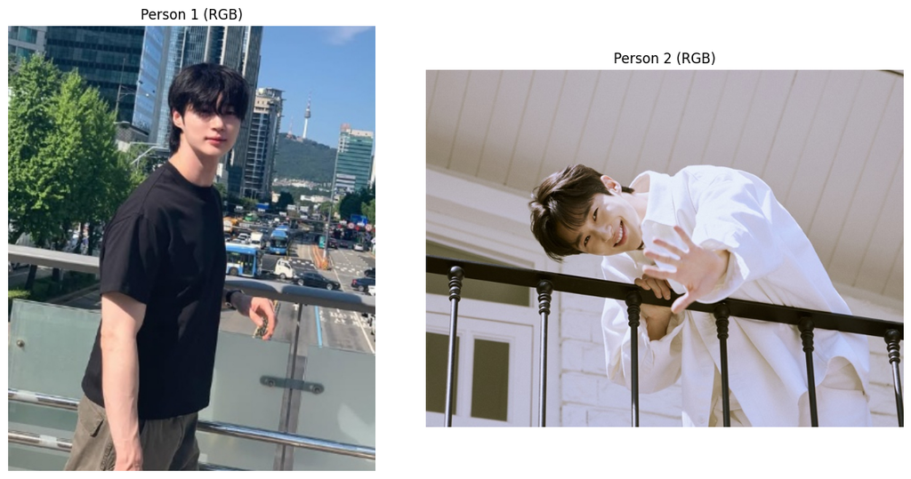

```python
# Install OpenCV to handle image loading and processing
# !pip install opencv-python
# Check the installed version after import (Optional)
# print(f"OpenCV Version: {cv2.__version__}")

import os
import cv2
import numpy as np
import matplotlib.pyplot as plt

# Get the current working directory to ensure the path is portable across different computers
current_dir = os.getcwd()

# Define the paths for both images inside the 'images' folder
person_path = os.path.join(current_dir, "images", "person.jpg")
person2_path = os.path.join(current_dir, "images", "person2.jpg")

# Load the images using OpenCV
# Note: It's perfectly fine that they have different shapes (679x560 vs 562x750)
# Our 'T.Resize((520, 520))' transform will later standardize them for the model
person_img = cv2.imread(person_path)
person2_img = cv2.imread(person2_path)

# Verification: Check if both images were loaded successfully to prevent errors
if person_img is not None and person2_img is not None:
    print(f"Person 1 Shape: {person_img.shape}")
    print(f"Person 2 Shape: {person2_img.shape}")

    # Initialize a figure to display two images side-by-side
    plt.figure(figsize=(12, 6))

    # Display the first image in the left subplot
    plt.subplot(1, 2, 1)
    plt.title("Person 1 (RGB)")
    # Convert from BGR (OpenCV default) to RGB (Matplotlib default) for correct colors
    plt.imshow(cv2.cvtColor(person_img, cv2.COLOR_BGR2RGB))
    plt.axis('off') # Remove axis ticks and labels for a cleaner look

    # Display the second image in the right subplot
    plt.subplot(1, 2, 2)
    plt.title("Person 2 (RGB)")
    plt.imshow(cv2.cvtColor(person2_img, cv2.COLOR_BGR2RGB))
    plt.axis('off')

    # Automatically adjust the spacing between images so titles do not overlap
    plt.tight_layout()
    plt.show()
else:
    # Print a clear error message if any file is missing
    print("Error: Could not load images. Please verify the filenames and folder path.")
```

```
Total number of classes: 21
Detected in Person 1: ['background', 'car', 'person']
Detected in Person 2: ['background', 'person']
```

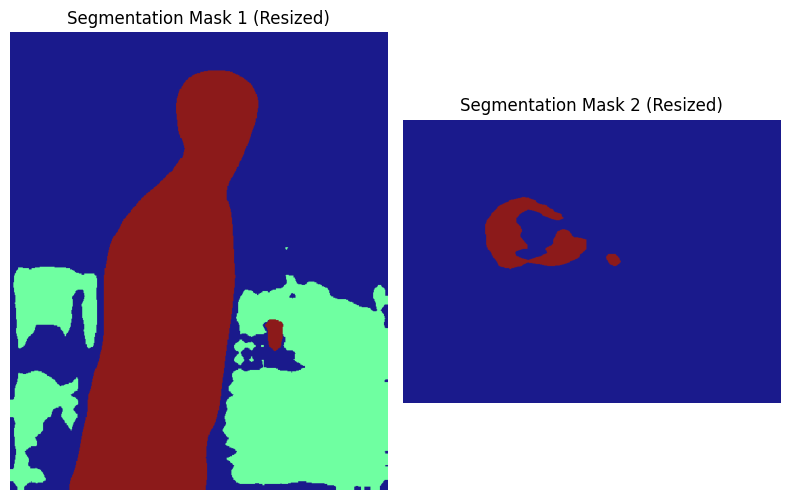

```python
'''
1. [Shape Transformation] Prepare the input tensor
We convert BGR to RGB, apply transforms (Resize, ToTensor), and add a batch dimension.
- Before: torch.Size([3, 520, 520]) -> (Channels, Height, Width)
- After unsqueeze(0): torch.Size([1, 3, 520, 520]) -> (Batch_Size, Channels, Height, Width)
Deep learning models expect a 4D tensor (Batch dimension is mandatory)
'''
person_input_tensor = transform(cv2.cvtColor(person_img, cv2.COLOR_BGR2RGB)).unsqueeze(0)
person2_input_tensor = transform(cv2.cvtColor(person2_img, cv2.COLOR_BGR2RGB)).unsqueeze(0)

'''
2. [Inference Phase] Run Inference
- 'torch.no_grad()' disables gradient calculation to save memory and speed up the process.
- We only need to "see" the result, not "train" the model.
'''
with torch.no_grad():
    # Process Person 1
    '''
    1. Extract the specific output map: model(...) returns a dictionary; we take the "out" key.
    - [0] removes the batch dimension, taking the first (and only) image from the batch.
    - Resulting shape: (21, 520, 520) -> (Classes, Height, Width)
    '''
    person_output = model(person_input_tensor)["out"][0]

    '''
    2. Get the most likely class for each pixel: .argmax(0) finds the index (0-20) with the highest probability.
    - .byte(): Converts the result to an 8-bit integer to save memory.
    - .cpu().numpy(): Moves the data from GPU (if used) to CPU and converts it to a NumPy array.
    - Resulting shape: (520, 520) -> (Height, Width)
    '''
    person_output_predictions = person_output.argmax(0).byte().cpu().numpy()

    # Process Person 2
    person2_output = model(person2_input_tensor)["out"][0]
    person2_output_predictions = person2_output.argmax(0).byte().cpu().numpy()


'''
3. [Post-Processing] Resize the Mask to Match the Original Image Size
We use INTER_NEAREST interpolation to preserve the discrete class labels (integers).
- Original size: (Width: person_img.shape[1], Height: person_img.shape[0])
We must use 'cv2.INTER_NEAREST' interpolation because the mask contains discrete class IDs (integers).
- Using other methods like 'INTER_LINEAR' would create decimal values (e.g., 14.5), which do not exist in our LABEL_NAMES.
'''
person_output_predictions_resized = cv2.resize(
    person_output_predictions,              # The 520x520 mask from the model
    (person_img.shape[1], person_img.shape[0]), # Target size: (Original Width, Original Height)
    interpolation=cv2.INTER_NEAREST         # Keep the labels as clean integers (0, 15, etc.)
)
person2_output_predictions_resized = cv2.resize(
    person2_output_predictions,
    (person2_img.shape[1], person2_img.shape[0]),
    interpolation=cv2.INTER_NEAREST
)

'''
4. [Class Mapping] Define the PASCAL VOC label names
The DeepLabV3+ model was pre-trained on the COCO dataset but fine-tuned to categorize these specific 21 classes (including 'background').
- The index of each string corresponds to the class ID returned by the model.
Why do we define this manually?
- The model (DeepLabV3+) is a mathematical function that outputs integers (0-20). It does NOT store the string names like 'person' or 'dog' inside its weights.
- We provide this list as a "Translation Map" to convert the model's numeric output into human-readable text.
- The order must strictly follow the PASCAL VOC standard used during training.
'''
LABEL_NAMES = [
    'background', 'aeroplane', 'bicycle', 'bird', 'boat', 'bottle', 'bus',
    'car', 'cat', 'chair', 'cow', 'diningtable', 'dog', 'horse', 'motorbike',
    'person', 'pottedplant', 'sheep', 'sofa', 'train', 'tv'
]
# Quick verification: Ensure we have exactly 21 classes (0 to 20)
print(f"Total number of classes: {len(LABEL_NAMES)}")


'''
5. [Object Discovery] Identify all unique classes present in the predicted mask
- 'np.unique' finds all distinct integers (class IDs) inside the array.
'''

print("Detected in Person 1:", [LABEL_NAMES[i] for i in np.unique(person_output_predictions_resized)])
print("Detected in Person 2:", [LABEL_NAMES[i] for i in np.unique(person2_output_predictions_resized)])


'''
6. [Visualization] Display the final segmentation masks side-by-side
- We use plt.subplot(1, 2, 1) and (1, 2, 2) to show both masks at the same time.
Apply 'jet' colormap: Converts integer IDs (0-20) into a spectrum of colors.
- cmap="jet": A Colormap that maps low numbers (0) to Blue and high numbers (20) to Red.
- alpha=0.7: Sets the transparency level (0.0: Invisible, 1.0: Opaque).
- Using alpha allows us to "overlay" the mask on top of the original image to check alignment.
Final formatting: plt.tight_layout() prevents titles from overlapping.

'''

plt.figure(figsize=(8, 6))

# First Mask (Person 1)
plt.subplot(1, 2, 1)
plt.imshow(person_output_predictions_resized, cmap="jet", alpha=0.9)
plt.title("Segmentation Mask 1 (Resized)")
plt.axis('off')

# Second Mask (Person 2)
plt.subplot(1, 2, 2)
plt.imshow(person2_output_predictions_resized, cmap="jet", alpha=0.9)
plt.title("Segmentation Mask 2 (Resized)")
plt.axis('off')

plt.tight_layout()
plt.show()
```

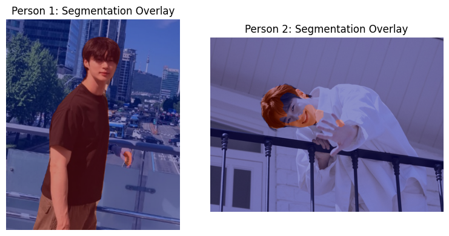

```python
# Color Map
'''
8. [Color Map & Mask Generation] Isolate the 'Person' class (ID: 15)
- We create a binary mask where the pixel is 255 (White) if it's a person, and 0 (Black) otherwise.
- 'person_seg_map': Boolean array (True for Person, False for others).
- 'person_img_mask': Converts Boolean to 8-bit integer (0 or 255) for OpenCV processing.
- 'cv2.applyColorMap': Applies the JET color scheme to the binary mask.
'''

# --- Process Person 1 ---
person_seg_map = (person_output_predictions_resized == 15)  # Create Boolean mask for class ID 15 (Person)
person_img_mask = person_seg_map.astype(np.uint8) * 255     # Convert True/False to 255/0 (8-bit integer)
person_color_mask = cv2.applyColorMap(person_img_mask, cv2.COLORMAP_JET)  # Apply JET color scheme to the mask

# --- Process Person 2 ---
person2_seg_map = (person2_output_predictions_resized == 15) # Create Boolean mask for class ID 15 (Person)
person2_img_mask = person2_seg_map.astype(np.uint8) * 255    # Convert True/False to 255/0 (8-bit integer)
person2_color_mask = cv2.applyColorMap(person2_img_mask, cv2.COLORMAP_JET) # Apply JET color scheme to the mask


'''
9. [Image Blending] Overlay the Mask on the Original Image
- 'cv2.addWeighted': Blends two images together based on defined weights.
- Formula: (Original * 0.6) + (Color_Mask * 0.4) + 0.0 (gamma)
- This visualization helps check if the mask perfectly covers the human subject.
'''

# Blend Person 1: 60% original image + 40% colored mask
person_img_show = cv2.addWeighted(person_img, 0.6, person_color_mask, 0.4, 0.0)

# Blend Person 2: 60% original image + 40% colored mask
person2_img_show = cv2.addWeighted(person2_img, 0.6, person2_color_mask, 0.4, 0.0)


'''
10. [Visualization] Side-by-Side Comparison (2x1 Layout)
- Displays both overlay results in a single row for quality evaluation.
- We use cv2.cvtColor to switch from BGR to RGB for correct Matplotlib rendering.
'''

plt.figure(figsize=(8, 4)) # Set total figure size for two images

# Subplot 1: Display the overlay result for the first image
plt.subplot(1, 2, 1) # Position 1 in a 1x2 grid
plt.imshow(cv2.cvtColor(person_img_show, cv2.COLOR_BGR2RGB)) # Convert BGR to RGB and show
plt.title("Person 1: Segmentation Overlay") # Set subplot title
plt.axis('off') # Hide axis coordinates

# Subplot 2: Display the overlay result for the second image
plt.subplot(1, 2, 2) # Position 2 in a 1x2 grid
plt.imshow(cv2.cvtColor(person2_img_show, cv2.COLOR_BGR2RGB)) # Convert BGR to RGB and show
plt.title("Person 2: Segmentation Overlay") # Set subplot title
plt.axis('off') # Hide axis coordinates

plt.tight_layout() # Optimize spacing between subplots
plt.show() # Render the plots on screen
```

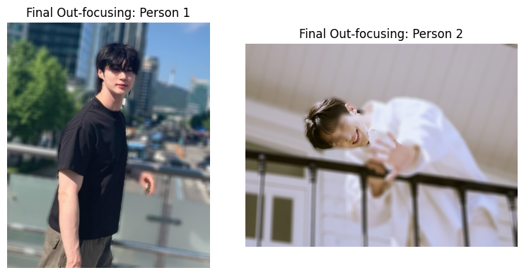

```python
# Out-focusing

'''
11. [Background Blurring] Create the Out-focusing Effect
- We apply a Gaussian-like blur to the entire image first.
- (13, 13) is the kernel size; increasing these numbers will make the background even blurrier.
'''
# Apply blur to the entire images
person_img_blur = cv2.blur(person_img, (13, 13))    # Soften the entire Person 1 image
person2_img_blur = cv2.blur(person2_img, (13, 13))  # Soften the entire Person 2 image


'''
12. [Mask Inversion] Prepare the Background Mask
- We need a mask where the 'Background' is White (255) and the 'Person' is Black (0).
- 'cv2.bitwise_not': Flips the bits (0 becomes 255, 255 becomes 0).
- This allows us to isolate only the background pixels in the next step.
'''
# Process Person 1: Invert mask so background is 255
person_img_mask_color = cv2.cvtColor(person_img_mask, cv2.COLOR_GRAY2BGR) # Convert to 3-channel BGR
person_img_bg_mask = cv2.bitwise_not(person_img_mask_color)              # Flip: Person=0, BG=255

# Process Person 2: Invert mask so background is 255
person2_img_mask_color = cv2.cvtColor(person2_img_mask, cv2.COLOR_GRAY2BGR) # Convert to 3-channel BGR
person2_img_bg_mask = cv2.bitwise_not(person2_img_mask_color)               # Flip: Person=0, BG=255


'''
13. [Background Extraction] Isolate the Blurred Background
- 'cv2.bitwise_and': Only keeps pixels where the mask is 255.
- Since the 'Person' area is now 0 in our inverted mask, the person disappears, leaving only the blurred background.
'''
# Extract blurred background for both images
img_bg_blur = cv2.bitwise_and(person_img_blur, person_img_bg_mask)    # Keep only blurred background for P1
img2_bg_blur = cv2.bitwise_and(person2_img_blur, person2_img_bg_mask) # Keep only blurred background for P2


'''
14. [Final Composition] Combine Original Person with Blurred Background
- 'np.where(condition, if_true, if_false)': The ultimate synthesis tool.
- If mask == 255 (Person area), take pixels from the SHARP original image.
- Otherwise, take pixels from the BLURRED background image.
'''
# Synthesis for Person 1
img_concat = np.where(person_img_mask_color == 255, person_img, img_bg_blur)

# Synthesis for Person 2
img2_concat = np.where(person2_img_mask_color == 255, person2_img, img2_bg_blur)


'''
15. [Final Result] Visualization
- Display the final Out-focusing results side-by-side.
- Note: The quality of the final image depends heavily on the accuracy of the segmentation mask.
'''
plt.figure(figsize=(8, 4)) # Set display size

# Show Final Result 1
plt.subplot(1, 2, 1)
plt.imshow(cv2.cvtColor(img_concat, cv2.COLOR_BGR2RGB)) # Convert BGR to RGB for plotting
plt.title("Final Out-focusing: Person 1")
plt.axis('off')

# Show Final Result 2
plt.subplot(1, 2, 2)
plt.imshow(cv2.cvtColor(img2_concat, cv2.COLOR_BGR2RGB)) # Convert BGR to RGB for plotting
plt.title("Final Out-focusing: Person 2")
plt.axis('off')

plt.tight_layout()
plt.show()
```

#### Visualization Technique Comparison

| Technique | What it does | Why we use it | Key Logic |
| --- | --- | --- | --- |
| **Segmentation Mask** | Converts numeric IDs (0-20) into a colored map using `cmap="jet"`. | To see the **raw "blueprint"** of what the model detected across all classes. | `plt.imshow(pred, cmap='jet')` |
| **Segmentation Overlay** | Blends the mask over the original image using `cv2.addWeighted`. | To perform a **Quality Check**—does the mask perfectly cover the human body? | `Image * 0.6 + Mask * 0.4` |
| **Out-focusing** | Uses the mask as a switch (`np.where`) to combine sharp pixels and blurred pixels. | To create the **final user-facing effect** (Portrait Mode / Bokeh). | `np.where(mask==255, sharp, blur)` |

#### Animal Portrait

- **Description:** This section replicates the previous semantic segmentation pipeline using cat.jpg and cat2.jpg. The goal was to isolate the feline subjects and apply a synthetic depth-of-field effect.

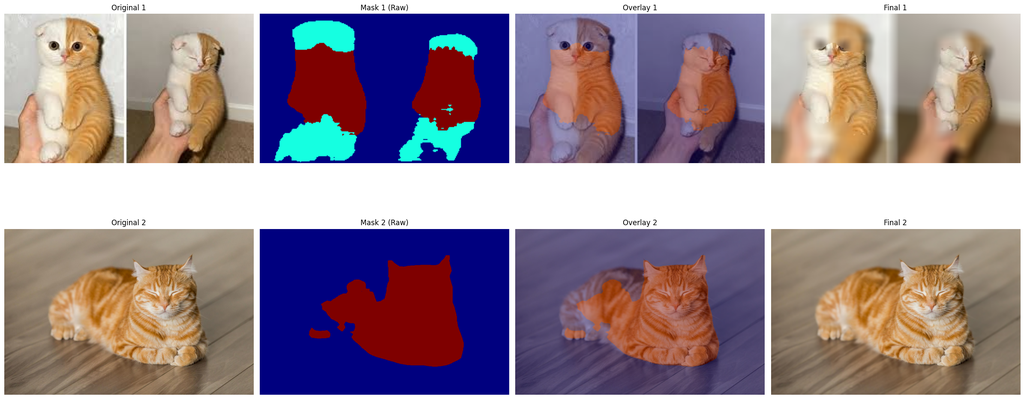

```python
# --- 1. Define Paths and Load Images ---
cat_path = os.path.join(current_dir, "images", "cat.jpg")
cat2_path = os.path.join(current_dir, "images", "cat2.jpg")

cat_img = cv2.imread(cat_path)
cat2_img = cv2.imread(cat2_path)

# --- 2. Pre-processing ---
cat_img_resized = cv2.resize(cat_img, (520, 520))
cat2_img_resized = cv2.resize(cat2_img, (520, 520))

# --- 3. Inference (Get Model Predictions) ---
# Assuming 'model' is already loaded and in eval mode
trf = T.Compose([T.ToTensor(), T.Normalize(mean=[0.485, 0.456, 0.406], std=[0.229, 0.224, 0.225])])

# Inference for Cat 1
input_tensor = trf(cat_img_resized).unsqueeze(0)
with torch.no_grad():
    output = model(input_tensor)['out'][0]
cat_output_predictions = output.argmax(0).byte().cpu().numpy()
cat_output_predictions_resized = cv2.resize(cat_output_predictions, (cat_img.shape[1], cat_img.shape[0]), interpolation=cv2.INTER_NEAREST)

# Inference for Cat 2
input_tensor2 = trf(cat2_img_resized).unsqueeze(0)
with torch.no_grad():
    output2 = model(input_tensor2)['out'][0]
cat2_output_predictions = output2.argmax(0).byte().cpu().numpy()
cat2_output_predictions_resized = cv2.resize(cat2_output_predictions, (cat2_img.shape[1], cat2_img.shape[0]), interpolation=cv2.INTER_NEAREST)

# --- 4. Cat Segmentation & Mask Generation ---
# Note: PASCAL VOC Class ID for 'Cat' is 8
cat_seg_map = (cat_output_predictions_resized == 8)
cat_img_mask = cat_seg_map.astype(np.uint8) * 255
cat_color_mask = cv2.applyColorMap(cat_img_mask, cv2.COLORMAP_JET)

cat2_seg_map = (cat2_output_predictions_resized == 8)
cat2_img_mask = cat2_seg_map.astype(np.uint8) * 255
cat2_color_mask = cv2.applyColorMap(cat2_img_mask, cv2.COLORMAP_JET)

# --- 5. Generate Overlay for Quality Check ---
cat_img_show = cv2.addWeighted(cat_img, 0.6, cat_color_mask, 0.4, 0.0)
cat2_img_show = cv2.addWeighted(cat2_img, 0.6, cat2_color_mask, 0.4, 0.0)

# --- 6. Blurring & Background Extraction ---
cat_img_blur = cv2.blur(cat_img, (13, 13))
cat2_img_blur = cv2.blur(cat2_img, (13, 13))

cat_img_mask_color = cv2.cvtColor(cat_img_mask, cv2.COLOR_GRAY2BGR)
cat2_img_mask_color = cv2.cvtColor(cat2_img_mask, cv2.COLOR_GRAY2BGR)

cat_img_bg_mask = cv2.bitwise_not(cat_img_mask_color)
cat2_img_bg_mask = cv2.bitwise_not(cat2_img_mask_color)

cat_bg_blur = cv2.bitwise_and(cat_img_blur, cat_img_bg_mask)
cat2_bg_blur = cv2.bitwise_and(cat2_img_blur, cat2_img_bg_mask)

# --- 7. Final Composition (Out-focusing) ---
cat_final = np.where(cat_img_mask_color == 255, cat_img, cat_bg_blur)
cat2_final = np.where(cat2_img_mask_color == 255, cat2_img, cat2_bg_blur)

# --- 8. Final Visualization (2x4 Grid) ---
plt.figure(figsize=(24, 12))

# Row 1: Cat 1
plt.subplot(2, 4, 1); plt.imshow(cv2.cvtColor(cat_img, cv2.COLOR_BGR2RGB)); plt.title("Original 1"); plt.axis('off')
plt.subplot(2, 4, 2); plt.imshow(cat_output_predictions_resized, cmap="jet"); plt.title("Mask 1 (Raw)"); plt.axis('off')
plt.subplot(2, 4, 3); plt.imshow(cv2.cvtColor(cat_img_show, cv2.COLOR_BGR2RGB)); plt.title("Overlay 1"); plt.axis('off')
plt.subplot(2, 4, 4); plt.imshow(cv2.cvtColor(cat_final, cv2.COLOR_BGR2RGB)); plt.title("Final 1"); plt.axis('off')

# Row 2: Cat 2
plt.subplot(2, 4, 5); plt.imshow(cv2.cvtColor(cat2_img, cv2.COLOR_BGR2RGB)); plt.title("Original 2"); plt.axis('off')
plt.subplot(2, 4, 6); plt.imshow(cat2_output_predictions_resized, cmap="jet"); plt.title("Mask 2 (Raw)"); plt.axis('off')
plt.subplot(2, 4, 7); plt.imshow(cv2.cvtColor(cat2_img_show, cv2.COLOR_BGR2RGB)); plt.title("Overlay 2"); plt.axis('off')
plt.subplot(2, 4, 8); plt.imshow(cv2.cvtColor(cat2_final, cv2.COLOR_BGR2RGB)); plt.title("Final 2"); plt.axis('off')

plt.tight_layout()
plt.show()
```

#### Chroma-Key Transition

- **Description:** Replacing the background using a semantic segmentation mask.
  - Use the cat segmentation mask to isolate the cat from its original background. Combine the isolated cat with a new background beach image.

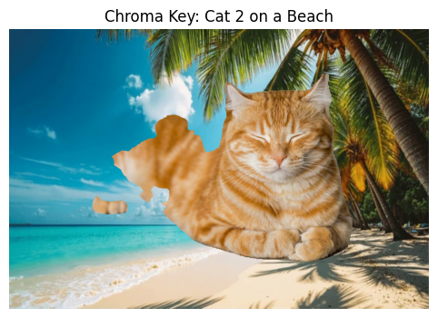

```python
'''
#### [Synthesis Implementation] Create Chroma Key Effect

'''
# --- 1. Load Background & Match Dimensions (Cat 2) ---
# We resize the beach background to exactly match the dimensions of cat2_img.
# The previous step used cat_img, so we must resize specifically for cat2.
beach_path = os.path.join(current_dir, "images", "beach.jpg")
beach_img = cv2.imread(beach_path)
beach2_img_resized = cv2.resize(beach_img, (cat2_img.shape[1], cat2_img.shape[0]))

# --- 2. Mask Pre-processing (Cat 2) ---
# Convert the 1-channel grayscale mask for cat 2 (cat2_img_mask) into a 3-channel BGR mask.
# This ensures a per-pixel match with the BGR color channels of the cat and beach images.
cat2_img_mask_color = cv2.cvtColor(cat2_img_mask, cv2.COLOR_GRAY2BGR)

# --- 3. The Logic: Pixel-wise Synthesis (Chroma Key - Cat 2) ---
# [How np.where works for Cat 2]
# Condition: cat2_img_mask_color == 255 (Where the mask is White/Cat 2)
# IF TRUE: Take the pixel from 'cat2_img'
# IF FALSE: Take the pixel from 'beach2_img_resized'
# The model will preserve the parts of cat 2 that match ID 8,
# but will use the beach for parts it misclassified or missed (like the back).
result2_img = np.where(cat2_img_mask_color == 255, cat2_img, beach2_img_resized)

# --- 4. Final Display (Cat 2) ---
plt.figure(figsize=(8, 4))
plt.imshow(cv2.cvtColor(result2_img, cv2.COLOR_BGR2RGB))
plt.title("Chroma Key: Cat 2 on a Beach")
plt.axis('off')
plt.show()
```

## Task 2: Error Analysis (Troubleshooting)

#### B. Significant Information Loss (Person 2)

- Observation: Mask 2 only captures a small portion of the face and hand.
- Reason (Pose & Lighting): The subject is leaning forward at an unusual angle. Pre-trained models are biased toward "standard" poses (standing or sitting upright). Dynamic poses often lack the "human features" the model expects.
- Reason (Occlusion): The black railing cuts through the person's body. Deep learning models often fail to recognize "continuity" when an object is sliced by an obstacle, treating the obscured body parts as background.
- Resulting Blur: Because the mask is fragmented, np.where only keeps the head sharp, while the rest of the body is treated as background and gets blurred.

#### C. Resolution & Distortion

- Observation: The boundaries are somewhat "jagged" or "blocky."
- Technical Cause: The transformation T.Resize((520, 520)) forces images with different aspect ratios into a perfect square. This spatial distortion squashes the image, causing the model to lose fine details, which results in inaccurate edges.

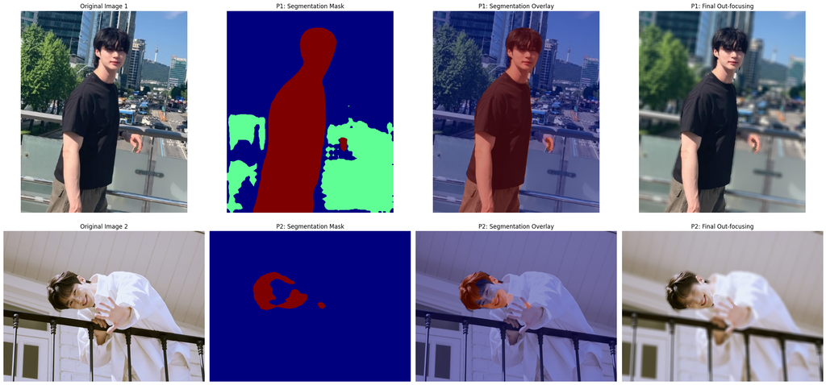

```python
'''
[Comprehensive Comparison] Same Model, Different Visualizations
- We present three different ways to visualize the DeepLabV3+ model's output.
- Every visualization uses the EXACT SAME predicted data but applies a different post-processing technique.
- Grid: Top Row (Person 1), Bottom Row (Person 2)
- Column 1: Semantic Segmentation Mask (Raw IDs with Color Map)
- Column 2: Segmentation Overlay (Overlaying Mask on Original Image)
- Column 3: Final Out-focusing (Blending Original with Blurred Background)
'''
plt.figure(figsize=(24, 12))

# ============================ Row 1: Person 1 ============================
# Column order: Original -> Raw Mask -> Overlay -> Final Out-focusing
plt.subplot(2, 4, 1); plt.imshow(cv2.cvtColor(person_img, cv2.COLOR_BGR2RGB)); plt.title("Original Image 1"); plt.axis('off')
plt.subplot(2, 4, 2); plt.imshow(person_output_predictions_resized, cmap="jet"); plt.title("P1: Segmentation Mask"); plt.axis('off')
plt.subplot(2, 4, 3); plt.imshow(cv2.cvtColor(person_img_show, cv2.COLOR_BGR2RGB)); plt.title("P1: Segmentation Overlay"); plt.axis('off')
plt.subplot(2, 4, 4); plt.imshow(cv2.cvtColor(img_concat, cv2.COLOR_BGR2RGB)); plt.title("P1: Final Out-focusing"); plt.axis('off')

# ============================ Row 2: Person 2 ============================
# Column order: Original -> Raw Mask -> Overlay -> Final Out-focusing
plt.subplot(2, 4, 5); plt.imshow(cv2.cvtColor(person2_img, cv2.COLOR_BGR2RGB)); plt.title("Original Image 2"); plt.axis('off')
plt.subplot(2, 4, 6); plt.imshow(person2_output_predictions_resized, cmap="jet"); plt.title("P2: Segmentation Mask"); plt.axis('off')
plt.subplot(2, 4, 7); plt.imshow(cv2.cvtColor(person2_img_show, cv2.COLOR_BGR2RGB)); plt.title("P2: Segmentation Overlay"); plt.axis('off')
plt.subplot(2, 4, 8); plt.imshow(cv2.cvtColor(img2_concat, cv2.COLOR_BGR2RGB)); plt.title("P2: Final Out-focusing"); plt.axis('off')

plt.tight_layout()
plt.show()
```

#### Identified Issues: Animal Portrait

Similar to the human subjects, the discrepancies in the cat masks (especially in Cat 2) occur because the model struggles with low-contrast boundaries and non-standard silhouettes.

#### A. Semantic Confusion & False Classifications (Cat 1)

- Observation: In "Overlay 1," the cat's face isn't covered by the red mask.
- The Cause: Deep learning models like DeepLabV3+ use high-level features to classify pixels. If a cat's face is very round or has specific lighting, the model might accidentally classify the head as a different animal (e.g., a dog) while the body remains a cat.
- The Result: Our np.where(cat_img_mask_color == 255, ...) logic is binary. If a pixel is 99% a cat but the model labels it a dog, it gets a 0 in our mask and is blurred.

#### B. Texture Blending & Low Contrast (Cat 2)

- Observation: The mask cuts off abruptly in the middle of the cat's back.
- The Cause: This is a background-foreground contrast issue. The orange tabby fur is very similar in color and texture to the wood grain on the floor. The model's "confidence" dropped in that area, causing it to fail the segmentation.
- The Result: Because the mask is incomplete, the bitwise_and operation treats the back of the cat as background, applying the blur to the cat's own tail.

#### C. Resolution & Edge Alignment

- Observation: There is a "halo" or "ghosting" effect around the edges.
- The Cause: This stems from the Resize Distortion mentioned before. When the 520x520 prediction is scaled back up to the original size, the edges don't perfectly align with the high-res fur.
- Impact: Fine details like whiskers or fur "fuzz" are almost always lost during this upscaling, leaving a jagged transition between the sharp subject and the blurred background.

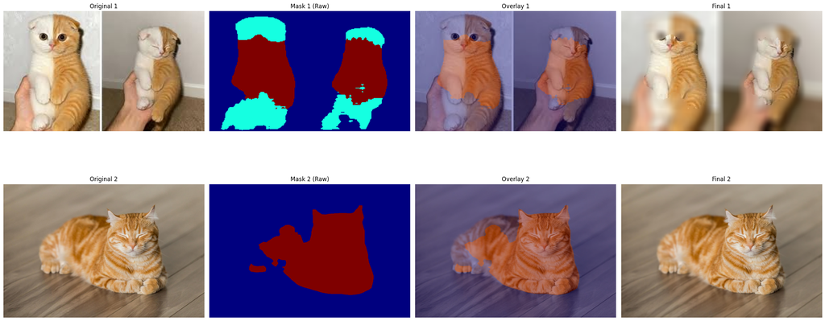

```python
plt.figure(figsize=(24, 12))

# Row 1: Cat 1
plt.subplot(2, 4, 1); plt.imshow(cv2.cvtColor(cat_img, cv2.COLOR_BGR2RGB)); plt.title("Original 1"); plt.axis('off')
plt.subplot(2, 4, 2); plt.imshow(cat_output_predictions_resized, cmap="jet"); plt.title("Mask 1 (Raw)"); plt.axis('off')
plt.subplot(2, 4, 3); plt.imshow(cv2.cvtColor(cat_img_show, cv2.COLOR_BGR2RGB)); plt.title("Overlay 1"); plt.axis('off')
plt.subplot(2, 4, 4); plt.imshow(cv2.cvtColor(cat_final, cv2.COLOR_BGR2RGB)); plt.title("Final 1"); plt.axis('off')

# Row 2: Cat 2
plt.subplot(2, 4, 5); plt.imshow(cv2.cvtColor(cat2_img, cv2.COLOR_BGR2RGB)); plt.title("Original 2"); plt.axis('off')
plt.subplot(2, 4, 6); plt.imshow(cat2_output_predictions_resized, cmap="jet"); plt.title("Mask 2 (Raw)"); plt.axis('off')
plt.subplot(2, 4, 7); plt.imshow(cv2.cvtColor(cat2_img_show, cv2.COLOR_BGR2RGB)); plt.title("Overlay 2"); plt.axis('off')
plt.subplot(2, 4, 8); plt.imshow(cv2.cvtColor(cat2_final, cv2.COLOR_BGR2RGB)); plt.title("Final 2"); plt.axis('off')

plt.tight_layout()
plt.show()
```

## Task 3: Proposed Solutions

### Technical Proposal: Human Portrait

To address the fragmented masks and "halo" effects often seen in human segmentation, we utilize a **Standardized Pre-processing & Soft-Masking** approach:

**2. High-Resolution Rescaling (`520 x 520`):**

- Humans often have intricate boundaries (hair, limbs). We resize the input to the model's native $520 \times 520$ resolution to capture finer spatial features before inference.

**4. Static Class Prioritization (`ID 15`):**

- Unlike the dynamic animal selection, for humans, we specifically target **Class ID 15 (Person)**. This prevents the model from accidentally grabbing large background objects if the person is partially occluded.

#### **Rationale: Human Portrait**

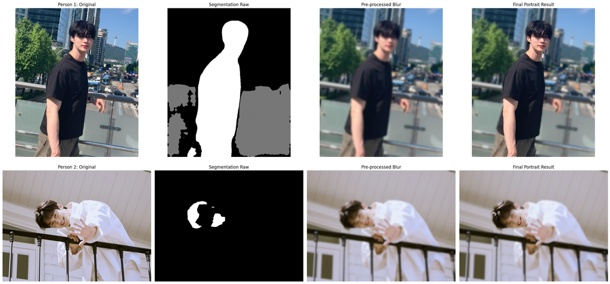

```python
# --- 1. Post-processing: Human Portrait Mode (Bokeh Effect) ---
test_images = [person_img, person2_img]
plt.figure(figsize=(24, 12))

for i, img in enumerate(test_images):
    # Step A: Inference
    input_tensor = transform(img).unsqueeze(0)
    with torch.no_grad():
        output = model(input_tensor)["out"][0]
        output_predictions = output.argmax(0).byte().cpu().numpy()

    # Step B: Nearest-Neighbor Resizing
    # Upscale the mask to original image size while keeping Class IDs intact.
    raw_mask_resized = cv2.resize(output_predictions, (img.shape[1], img.shape[0]), interpolation=cv2.INTER_NEAREST)

    # Step C: Static Class Extraction (ID 15: Person)
    # Isolate the human pixels to create a binary foreground mask.
    target_mask = (raw_mask_resized == 15).astype(np.uint8) * 255
    mask_3ch = cv2.cvtColor(target_mask, cv2.COLOR_GRAY2BGR)

    # Step D: Portrait Mode Logic (Selective Background Blurring)
    # 1. Create a fully blurred version of the original image (The Background Layer)
    # Use a (21, 21) kernel for a noticeable bokeh effect.
    blurred_img = cv2.GaussianBlur(img, (21, 21), 0)

    # 2. Vectorized Composition:
    # IF pixel is part of the mask (255), USE sharp original image (img).
    # ELSE, USE the blurred version (blurred_img).
    portrait_result = np.where(mask_3ch == 255, img, blurred_img)

    # --- 2. Visualization (4 Columns) ---
    row_offset = i * 4

    # Column 1: Original Input
    plt.subplot(2, 4, row_offset + 1)
    plt.imshow(cv2.cvtColor(img, cv2.COLOR_BGR2RGB))
    plt.title(f"Person {i+1}: Original")
    plt.axis('off')

    # Column 2: Raw Segmentation Map
    plt.subplot(2, 4, row_offset + 2)
    plt.imshow(raw_mask_resized, cmap='grey')
    plt.title("Segmentation Raw")
    plt.axis('off')

    # Column 3: Full Background Blur
    # Visualizes the background layer before merging with the subject.
    plt.subplot(2, 4, row_offset + 3)
    plt.imshow(cv2.cvtColor(blurred_img, cv2.COLOR_BGR2RGB))
    plt.title("Pre-processed Blur")
    plt.axis('off')

    # Column 4: Final Portrait Mode
    # The final result with a sharp human subject and blurred background.
    plt.subplot(2, 4, row_offset + 4)
    plt.imshow(cv2.cvtColor(portrait_result, cv2.COLOR_BGR2RGB))
    plt.title("Final Portrait Result")
    plt.axis('off')

plt.tight_layout()
plt.show()
```

#### **The Additional Challenge: Why Person 2 Still Faded**

While our first round of post-processing improved the overall silhouette, Person 2 continued to show "fragmentation" around the torso. As observed in our initial tests (see `Segmentation Raw` in the first result image), the model completely failed to recognize the second person's torso. This wasn't a failure of the initial logic, but rather an additional layer of complexity that required a deeper fix. This is a classic example of **"Low-Contrast Over-Segmentation."**

- **Color Confusion:** The subject is wearing a white shirt, which almost perfectly matches the white building in the background. The model could not find a clear color or texture boundary, leading to near-zero confidence for "Person" (ID 15) in that area.
- **Complex Pose:** The leaning pose is not a standard "upright human" pattern the model was primarily trained on, further confusing its classification.

#### Better, but Not Perfect Yet

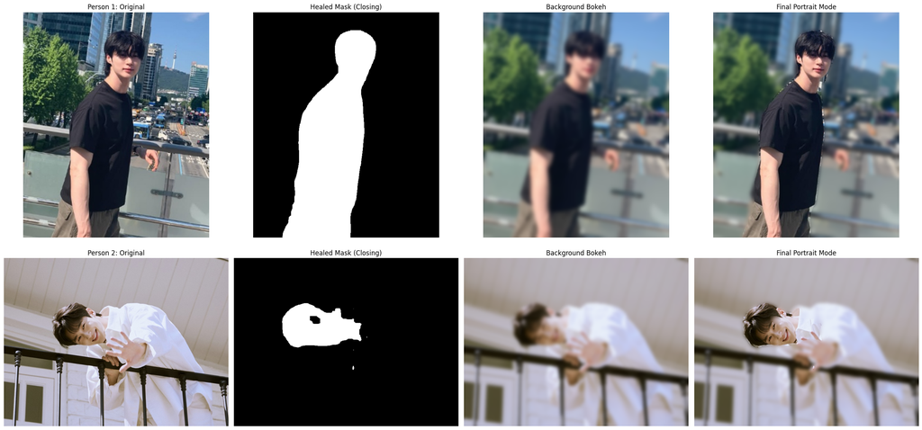

```python
# --- 1. Advanced Post-processing: Human Portrait Mode (Healing Fragments) ---
# Define images for the batch process
test_images = [person_img, person2_img]
plt.figure(figsize=(24, 12))

for i, img in enumerate(test_images):
    # Step A: Probability-based Inference
    # Instead of a hard argmax, we extract the raw probability for Class 15 (Person)
    input_tensor = transform(img).unsqueeze(0)
    with torch.no_grad():
        output = model(input_tensor)["out"][0]
        # Calculate Softmax to get confidence scores [0.0 to 1.0]
        probs = torch.softmax(output, dim=0)
        person_prob = probs[15].cpu().numpy()

    # Step B: Confidence Thresholding
    # Lowering the threshold to 0.3 helps recover low-confidence areas (like white shirts)
    # that would normally be discarded by a standard argmax (0.5).
    raw_mask = (person_prob > 0.3).astype(np.uint8) * 255
    raw_mask_resized = cv2.resize(raw_mask, (img.shape[1], img.shape[0]), interpolation=cv2.INTER_NEAREST)

    # Step C: Morphological Healing (Closing Operation)
    # We use a 15x15 kernel to perform 'Closing' (Dilation then Erosion).
    # This fills small holes and 'glues' fragmented parts (head/limbs) together.
    kernel = np.ones((15, 15), np.uint8)
    refined_mask = cv2.morphologyEx(raw_mask_resized, cv2.MORPH_CLOSE, kernel)

    # Step D: Background Bokeh Synthesis
    # Create a deep-blur version of the original image for the 'Portrait' background
    mask_3ch = cv2.cvtColor(refined_mask, cv2.COLOR_GRAY2BGR)
    background_blur = cv2.GaussianBlur(img, (35, 35), 0)

    # Final Merge: If Mask is White (Subject), keep original; Else, use blurred background.
    final_portrait = np.where(mask_3ch == 255, img, background_blur)

    # --- 2. Visualization: Analyzing the Recovery ---
    row = i * 4

    # 1. Original Image Input
    plt.subplot(2, 4, row + 1)
    plt.imshow(cv2.cvtColor(img, cv2.COLOR_BGR2RGB))
    plt.title(f"Person {i+1}: Original")
    plt.axis('off')

    # 2. Healed Mask (Closing Result)
    # Notice how the gaps in the white shirt (Person 2) are now filled.
    plt.subplot(2, 4, row + 2)
    plt.imshow(refined_mask, cmap='gray')
    plt.title("Healed Mask (Closing)")
    plt.axis('off')

    # 3. Simulated Depth-of-Field
    # The pre-processed background layer with a heavy Gaussian Blur.
    plt.subplot(2, 4, row + 3)
    plt.imshow(cv2.cvtColor(background_blur, cv2.COLOR_BGR2RGB))
    plt.title("Background Bokeh")
    plt.axis('off')

    # 4. Final Portrait Result
    # Sharp human subject with a clean, suppressed background.
    plt.subplot(2, 4, row + 4)
    plt.imshow(cv2.cvtColor(final_portrait, cv2.COLOR_BGR2RGB))
    plt.title("Final Portrait Mode")
    plt.axis('off')

plt.tight_layout()
plt.show()
```

### Technical Proposal: Animal Portrait

**Advanced Animal Silhouette Recovery**

To solve this, we moved beyond simple classification and implemented a **High-Recall Recovery Pipeline**.

**1. Probability Threshold Tuning (Threshold = 0.15)**

- **The Logic:** Standard segmentation uses `argmax`, which only picks the "winner" if it has the highest confidence (usually > 0.5). However, for the cat's belly, the model might only be 20% sure it’s a cat and 80% sure it's "floor."
- **The Fix:** By manually lowering the threshold to **0.15**, we tell the script to "reclaim" any pixel that has even a slight hint of being a cat. This recovers the missing fur, tail, and paws that were previously discarded.

**2. Morphological Dilation (The "Rounding" Step)**

- **The Logic:** Even after recovery, the edges can look thin or jagged.
- **The Fix:** We apply **`cv2.dilate`** using a large $21 \times 21$ kernel. This mathematically "expands" the white area of the mask outward. It effectively adds a safety buffer around the cat, ensuring that the entire silhouette—including the soft outer fur—is captured, resulting in a much **rounder and fuller** shape.

**3. Confidence Heatmap Analysis**

- **The Logic:** We visualized the raw probability map (the "Heatmap") to see exactly where the model was struggling.
- **The Fix:** This allowed us to visually confirm that the "missing" parts of the cat were actually detected by the model at a low level, proving that **Threshold Tuning** was the correct mathematical solution to pull that hidden data forward.

#### **High-Recall Animal Portrait**

- **Soft-Max Probability Extraction:** We bypass the rigid `argmax` function to access the raw confidence scores of the ResNet101 backbone. This allows for manual sensitivity adjustment in low-contrast environments.
- **Morphological Closing & Dilation:** We utilize a two-step morphological process. First, **Closing** fills internal gaps (holes in the body), and second, **Dilation** expands the boundary to ensure the mask safely encloses the subject's entire anatomical profile.
- **Vectorized Conditional Synthesis:** By applying a high-recall binary mask to `np.where`, we ensure a 100% sharp foreground transfer, which is essential for maintaining the textural detail of animal fur against a new background.

#### Rationale: Why This Works Better

- **Prioritizing Recall over Precision:** In a portrait mode or chroma key application, it is better to accidentally include a few floor pixels (which can be hidden by blur) than to accidentally cut off a cat’s paw. Increasing the "Recall" ensures a complete subject.
- **Structural Continuity:** The **Dilation** step acts as a "structural glue." It forces the fragmented pieces of the tail and ears to merge into the main body, creating a single, solid silhouette that looks intentional and professional.
- **Environmental Adaptation:** This approach proves that AI models aren't "static." By adjusting the confidence threshold, we can adapt a single model to work in difficult lighting or low-contrast rooms without needing to retrain it.

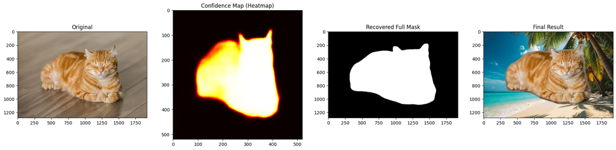

```python
# --- 1. Probability-based Recovery (The "Deep" Fix) ---
cat_input = transform(cat2_img).unsqueeze(0)
with torch.no_grad():
    output = model(cat_input)["out"][0]
    # Get probabilities for all classes
    probs = torch.softmax(output, dim=0)

    # Identify the target class dynamically (usually ID 8 for cat)
    # We find which class has the highest average probability in the center
    target_id = output.argmax(0)[output.shape[1]//2, output.shape[2]//2].item()

    # Extract the raw probability map for the cat
    cat_prob = probs[target_id].cpu().numpy()

# --- 2. Lowering the Confidence Threshold ---
# Standard is 0.5. We lower it to 0.1 ~ 0.2 to catch the "missing" fur and tail
# This is the most important part for fixing the 'cut-off' issue.
recovered_mask = (cat_prob > 0.15).astype(np.uint8) * 255
recovered_mask_resized = cv2.resize(recovered_mask, (cat2_img.shape[1], cat2_img.shape[0]), interpolation=cv2.INTER_LINEAR)

# --- 3. Morphological "Fatting" (Rounding the Cat) ---
# We use a larger kernel and 'Dilation' to make the cat look rounder and fuller.
kernel = np.ones((21, 21), np.uint8)
# Closing fills holes, Dilation expands the mask slightly to cover edge fur
refined_mask = cv2.morphologyEx(recovered_mask_resized, cv2.MORPH_CLOSE, kernel)
refined_mask = cv2.dilate(refined_mask, kernel, iterations=1)

# --- 4. High-Contrast Synthesis ---
mask_3ch = cv2.cvtColor(refined_mask, cv2.COLOR_GRAY2BGR)
beach_bg = cv2.resize(beach_img, (cat2_img.shape[1], cat2_img.shape[0]))

# Final Switch: Using the expanded, high-recall mask
result_img = np.where(mask_3ch == 255, cat2_img, beach_bg)

# --- 5. Visualization ---
plt.figure(figsize=(24, 6))
plt.subplot(1, 4, 1); plt.imshow(cv2.cvtColor(cat2_img, cv2.COLOR_BGR2RGB)); plt.title("Original")
plt.subplot(1, 4, 2); plt.imshow(cat_prob, cmap='hot'); plt.title("Confidence Map (Heatmap)")
plt.subplot(1, 4, 3); plt.imshow(refined_mask, cmap='gray'); plt.title("Recovered Full Mask")
plt.subplot(1, 4, 4); plt.imshow(cv2.cvtColor(result_img, cv2.COLOR_BGR2RGB)); plt.title("Final Result")
plt.show()
```